# Team Project: Data Analysis Project Report: Consumer Attractions In Social Network Era

Jianye Han (jianyeh2), Zach Litz (zlitz2), Megan Masanz (mjneuman)

July 29, 2017

# **I**. Introduction

In this project, we will be examining a dataset [1] that contains social media information for a particular cosmetics brand. The data contains information about posts that were published on the brand’s Facebook page during the year of 2014. There are approximately 500 records in this dataset (prior to any cleaning).

The information includes what would be expected from social media page metrics such as `Page total like`, `Lifetime Post Consumption`, `Total Interactions`, `Post Month`, and `Type` (see [Table A.1] for a complete list of variables).

It is widely understood that Facebook marketing is an important tool used by modern data businesses in order to create social awareness and increase revenue. For this project, we are operating under the assumption that `Lifetime Post Consumers` is a good metric for evaluating how effective a Facebook post is in achieving advertising goals. In other words, a large value for `Lifetime Post Consumers` corresponds to a high social awareness which can lead to increased revenue. Thus, it seems to be beneficial to understand how `Lifetime Post Consumers` is explained by the other variables in the dataset in an effort to increase `Lifetime Post Consumers`.

Because our goal is to explain `Lifetime Post Consumers`, we will try to find the smallest model that gives good results. We are interested in a smaller and simpler model in order to ensure the model is understandable. To do this, we will use various techniques for model selection and quality criteria. These techniques will be described in the methods section.

# **II**. Methods

The first step in our analysis is to prepare the data. The data is prepared as follows:

1. Remove all incomplete records. For our purposes, an incomplete record is any record which has empty or NA values. This steps results in a total of 5 records being removed.
2. Convert numeric categorical variables to proper factors. We convert
   - `Type`
   - `Category`
   - `Post Month`
   - `Post Hours`
   - `Post Weekday`
   - `Paid`
3. Remove the `Total Interactions` variable because it is perfectly correlated with the response.

### Variable Exploration

#### The Additive Model

Our first step into exploring and analyzing this data is to create a full additive model. This additive model will include all predictors in the dataset. There are no transformations or interactions. (See [Table A.1] for a complete description of variables). The response variable is `Lifetime Post Consumers`.

```r
full_additive_model <- lm(Lifetime.Post.Consumers ~ ., data = complete_data)
```

We begin our analysis by trying to develop an understanding of how the predictor variables relate to each other. Here we will look at $R^2_j$ and the variance inflation factor (VIF). This information will help us understand the effect of collinearity on the variance of the regression estimates, as well as the proportion of observed variation each predictor as explained by the other predictors. [Table 2.1] shows the $R^2_j$ and VIF values for each applicable predictor used in the fully additive model (note that categorical predictors have `NA` values).

####Table 2.1

Table 2.1 - Rj^2 and VIF values for full additive model

| predictor | rj_squared | vif |
| --- | --- | --- |
| Page.total.likes | 0.99 | 154.6 |
| Type | NA | NA |
| Category | NA | NA |
| Post.Month | NA | NA |
| Post.Weekday | NA | NA |
| Post.Hour | NA | NA |
| Paid | NA | NA |
| Lifetime.Post.Total.Reach | 0.96 | 24.2 |
| Lifetime.Post.Total.Impressions | 0.97 | 35.4 |
| Lifetime.Engaged.Users | 0.89 | 9.3 |
| Lifetime.Post.Consumptions | 0.61 | 2.6 |
| Lifetime.Post.Impressions.by.people.who.have.liked.your.Page | 0.96 | 24.8 |
| Lifetime.Post.reach.by.people.who.like.your.Page | 0.91 | 11.6 |
| Lifetime.People.who.have.liked.your.Page.and.engaged.with.your.post | 0.89 | 9.5 |
| comment | 0.81 | 5.3 |
| like | 0.91 | 11.1 |
| share | 0.90 | 9.6 |

The high $R^2_j$ values in [Table 2.1] show that each given predictor can be explained by other predictors. This suggest that we can remove some of the predictors from this model. The high VIF values indicate that our estimates of the $\beta$ parameters are going to be highly variable. This high variability is undesirable given our goal of using the model for explanation. Having established that this is a poor model for explanation, we will begin to simplify the model.

#### Additive Model Selection

We will start the selection process by using the R `step()` function to perform forward and backward searches. In addition to doing AIC and BIC searches, we will also do a forward search using 0 penalty which means only RSS matters (lower RSS wins). Instead of taking the model returned by the `step()` function, we will keep a list of the models selected at each step. Then we will perform ANOVA F-tests for each group of models to find the smallest model that is significant. This will give us the five models described in table 2.2. We will then find the best model from this group which will be used for the next step.

####Table 2.2

Table 2.2 - Model Selection Description

| Model | Description |
| --- | --- |
| rss_fwd_model | Smallest significant model found using forward search with no penalty |
| aic_fwd_model | Smallest significant model found using forward search with penalty 2P |
| bic_fwd_model | Smallest significant model found using forward search with penalty log(n) |
| aic_bwd_model | Smallest significant model found using backward search with penalty 2p |
| bic_bwd_model | Smallest significant model found using backward search with penalty log(n) |

Running through this process gives us five models.

The `rss_fwd_model` (which uses the forward selection process with no penalty, meaning only RSS matters) has the predictors:

```
Lifetime.Engaged.Users + like + share + Lifetime.People.who.have.liked.your.Page.and.engaged.with.your.post +
    Post.Month + Lifetime.Post.Consumptions + comment + Lifetime.Post.Total.Reach
```

The `aic_fwd_model` has the predictors:

```
Lifetime.Engaged.Users + like + share + Lifetime.People.who.have.liked.your.Page.and.engaged.with.your.post +
    Lifetime.Post.Consumptions + Post.Month + comment + Lifetime.Post.Total.Reach +
    Type + Lifetime.Post.Total.Impressions + Lifetime.Post.Impressions.by.people.who.have.liked.your.Page
```

The `bic_fwd_model` has the predictors:

```
Lifetime.Engaged.Users + like + share + Lifetime.People.who.have.liked.your.Page.and.engaged.with.your.post +
    Lifetime.Post.Consumptions + comment + Page.total.likes +
    Lifetime.Post.Total.Reach
```

The `aic_bwd_model` has the predictors:

```
Type + Post.Month + Lifetime.Post.Total.Reach + Lifetime.Post.Total.Impressions +
    Lifetime.Engaged.Users + Lifetime.Post.Consumptions + Lifetime.Post.Impressions.by.people.who.have.liked.your.Page +
    Lifetime.People.who.have.liked.your.Page.and.engaged.with.your.post +
    comment + like + share
```

The `bic_bwd_model` has the predictors:

```
Page.total.likes + Lifetime.Post.Total.Reach + Lifetime.Post.Total.Impressions +
    Lifetime.Engaged.Users + Lifetime.Post.Consumptions + Lifetime.People.who.have.liked.your.Page.and.engaged.with.your.post +
    comment + like + share
```

Once again, we will look at the $R^2_j$ and VIF values for the models. [Table 2.3], [Table 2.4], [Table 2.5], [Table 2.6], and [Table 2.7] show these values for the `rss_fwd_model`, `aic_fwd_model`, `bic_fwd_model`, `aic_bwd_model`, and `bic_bwd_model` respectively.

Note that the categorical variables will be displayed in the table as `NA`, this is due to the fact that these predictors will add many variables into the model. For a categorical variable with k categories, it will introduce k-1 predictor variables, so for simplicity of analysis, these will be looked at seperately during our analysis in section Categorical Predictors.

####Table 2.3

Table 2.3 - Rj^2 and VIF values for rss_fwd_model

| predictor | rj_squared | vif |
| --- | --- | --- |
| Lifetime.Engaged.Users | 0.84 | 6.1 |
| like | 0.86 | 7.2 |
| share | 0.87 | 7.9 |
| Lifetime.People.who.have.liked.your.Page.and.engaged.with.your.post | 0.74 | 3.8 |
| Post.Month | NA | NA |
| Lifetime.Post.Consumptions | 0.53 | 2.1 |
| comment | 0.78 | 4.6 |
| Lifetime.Post.Total.Reach | 0.45 | 1.8 |

####Table 2.4

Table 2.4 - Rj^2 and VIF values for aic_fwd_model

| predictor | rj_squared | vif |
| --- | --- | --- |
| Lifetime.Engaged.Users | 0.85 | 6.5 |
| like | 0.90 | 9.6 |
| share | 0.89 | 8.8 |
| Lifetime.People.who.have.liked.your.Page.and.engaged.with.your.post | 0.83 | 6.0 |
| Lifetime.Post.Consumptions | 0.54 | 2.2 |
| Post.Month | NA | NA |
| comment | 0.79 | 4.7 |
| Lifetime.Post.Total.Reach | 0.89 | 9.1 |
| Type | NA | NA |
| Lifetime.Post.Total.Impressions | 0.95 | 19.5 |
| Lifetime.Post.Impressions.by.people.who.have.liked.your.Page | 0.91 | 11.2 |

####Table 2.5

Table 2.5 - Rj^2 and VIF values for bic_fwd_model

| predictor | rj_squared | vif |
| --- | --- | --- |
| Lifetime.Engaged.Users | 0.83 | 6.0 |
| like | 0.86 | 7.0 |
| share | 0.87 | 7.5 |
| Lifetime.People.who.have.liked.your.Page.and.engaged.with.your.post | 0.73 | 3.7 |
| Lifetime.Post.Consumptions | 0.51 | 2.0 |
| comment | 0.78 | 4.5 |
| Page.total.likes | 0.10 | 1.1 |
| Lifetime.Post.Total.Reach | 0.43 | 1.8 |

####Table 2.6

Table 2.6 - Rj^2 and VIF values for aic_bwd_model

| predictor | rj_squared | vif |
| --- | --- | --- |
| Type | NA | NA |
| Post.Month | NA | NA |
| Lifetime.Post.Total.Reach | 0.89 | 9.1 |
| Lifetime.Post.Total.Impressions | 0.95 | 19.5 |
| Lifetime.Engaged.Users | 0.85 | 6.5 |
| Lifetime.Post.Consumptions | 0.54 | 2.2 |
| Lifetime.Post.Impressions.by.people.who.have.liked.your.Page | 0.91 | 11.2 |
| Lifetime.People.who.have.liked.your.Page.and.engaged.with.your.post | 0.83 | 6.0 |
| comment | 0.79 | 4.7 |
| like | 0.90 | 9.6 |
| share | 0.89 | 8.8 |

####Table 2.7

Table 2.7 - Rj^2 and VIF values for bic_bwd_model

| predictor | rj_squared | vif |
| --- | --- | --- |
| Page.total.likes | 0.12 | 1.1 |
| Lifetime.Post.Total.Reach | 0.67 | 3.0 |
| Lifetime.Post.Total.Impressions | 0.52 | 2.1 |
| Lifetime.Engaged.Users | 0.84 | 6.2 |
| Lifetime.Post.Consumptions | 0.51 | 2.0 |
| Lifetime.People.who.have.liked.your.Page.and.engaged.with.your.post | 0.74 | 3.9 |
| comment | 0.78 | 4.6 |
| like | 0.86 | 7.0 |
| share | 0.87 | 7.5 |

It is easy to see that all of the models have much less collinearity issues than the original full additive model (based on the much smaller VIF values).

Given both the `rss_fwd_model` and the `aic_fwd_model` model included `Post.Month` as a categorical variable that was included in the model, we will explore introducing this categorical variable into the model and the possibility of interaction with the other variables.

Table 2.8 shows the variables included in each of the five models.

####Table 2.8

Table 2.8 - MLR Additive Model Variable Analysis

| Variable | RSS Forward | AIC Forward | BIC Forward | AIC Backward | BIC Backward |
| --- | --- | --- | --- | --- | --- |
| Page.total.likes | FALSE | FALSE | TRUE | FALSE | TRUE |
| Type | FALSE | TRUE | FALSE | TRUE | FALSE |
| Category | FALSE | FALSE | FALSE | FALSE | FALSE |
| Post.Month | TRUE | TRUE | FALSE | TRUE | FALSE |
| Post.Weekday | FALSE | FALSE | FALSE | FALSE | FALSE |
| Post.Hour | FALSE | FALSE | FALSE | FALSE | FALSE |
| Paid | FALSE | FALSE | FALSE | FALSE | FALSE |
| Lifetime.Post.Total.Reach | TRUE | TRUE | TRUE | TRUE | TRUE |
| Lifetime.Post.Total.Impressions | FALSE | TRUE | FALSE | TRUE | TRUE |
| Lifetime.Engaged.Users | TRUE | TRUE | TRUE | TRUE | TRUE |
| Lifetime.Post.Consumptions | TRUE | TRUE | TRUE | TRUE | TRUE |
| Lifetime.Post.Impressions.by.people.who.have.liked.your.Page | FALSE | TRUE | FALSE | TRUE | FALSE |
| Lifetime.Post.reach.by.people.who.like.your.Page | FALSE | FALSE | FALSE | FALSE | FALSE |
| Lifetime.People.who.have.liked.your.Page.and.engaged.with.your.post | TRUE | TRUE | TRUE | TRUE | TRUE |
| comment | TRUE | TRUE | TRUE | TRUE | TRUE |
| like | TRUE | TRUE | TRUE | TRUE | TRUE |
| share | TRUE | TRUE | TRUE | TRUE | TRUE |

[Table 2.8] gives us more of an idea on which variables should be used in our analysis. We will look at these variables more closely by creating a pairs plot that includes only the variables that are common to all models.

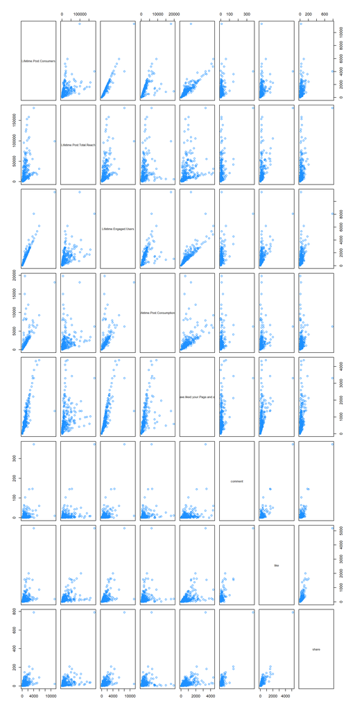

Figure 2.1 - Pairs Plot of Important Variables

- share
- like
- comment
- Lifetime.People.who.have.liked.your.Page.and.engaged.with.your.post
- Lifetime.Engaged.Users

There are 2 variables we should explore futher namely: - Lifetime.Post.Impressions.by.people.who.have.liked.your.Page - Lifetime.Post.reach.by.people.who.like.your.Page

```r
PostImpressionsModel = lm(Lifetime.Post.Impressions.by.people.who.have.liked.your.Page ~
                        Lifetime.Engaged.Users + like +
                        share + Lifetime.People.who.have.liked.your.Page.and.engaged.with.your.post +
                        comment, data  = complete_data)

ModelWOutImpressions = lm(Lifetime.Post.Consumers  ~ Lifetime.Engaged.Users + like +
                            share + Lifetime.People.who.have.liked.your.Page.and.engaged.with.your.post
                          + comment, data  = complete_data)
```

The partial correlation coefficient of `Lifetime.Post.Impressions.by.people.who.have.liked.your.Page` and `Lifetime.Post.Consumers` with the effects of the other variables in the model removed with a value of 0.05 serves as additional justication that this predictors should not end up in our final selected model.

```r
cor(resid(PostImpressionsModel), resid(ModelWOutImpressions))
```

```
## [1] 0.046
```

[output not shown]

This information provide clarity that we should exclude these two predictor variables from further analysis.

#### Categorical Predictors

```r
null_model = lm(Lifetime.Post.Consumers ~ Lifetime.Engaged.Users + like +
                  share + Lifetime.People.who.have.liked.your.Page.and.engaged.with.your.post +
                  comment, data = complete_data)

full_model = lm(Lifetime.Post.Consumers ~ Lifetime.Engaged.Users + like +
                  share + Lifetime.People.who.have.liked.your.Page.and.engaged.with.your.post +
                  comment + Post.Month, data = complete_data)

anova(null_model, full_model)$"Pr(>F)"[2]
```

```
## [1] 4.1e-07
```

[output not shown]

Table 2.9 - Categorical Post.Month p-values

| Month | p-value |
| --- | --- |
| Post.Month2 | 0.132081636785593 |
| Post.Month3 | 0.427337798145984 |
| Post.Month4 | 0.615666711739369 |
| Post.Month5 | 0.421115245907413 |
| Post.Month6 | 0.47192398540812 |
| Post.Month7 | 0.858347227842278 |
| Post.Month8 | 0.780589994196346 |
| Post.Month9 | 0.498918951259253 |
| Post.Month10 | 0.685807058738021 |
| Post.Month11 | 0.0239254021126287 |
| Post.Month12 | 0.00288957272944549 |

Given adding these would explode our model, we will explore the possibility of adding either `Post.Month12` or `Post.Month11` given these 2 have the lowest p-values of all the the months.

```r
PostMonth12 = 1 * as.numeric(complete_data$Post.Month == "12")
PostMonth11 = 1 * as.numeric(complete_data$Post.Month == "11")

complete_data = cbind(complete_data, PostMonth12,  PostMonth11)


model_month = lm(Lifetime.Post.Consumers  ~ Lifetime.Engaged.Users + like +
                            share + Lifetime.People.who.have.liked.your.Page.and.engaged.with.your.post
                          + comment + Post.Month, data = complete_data)

model_base = lm(Lifetime.Post.Consumers  ~ Lifetime.Engaged.Users + like +
                            share + Lifetime.People.who.have.liked.your.Page.and.engaged.with.your.post
                          + comment , data  = complete_data)

model_month11 = lm(Lifetime.Post.Consumers  ~ Lifetime.Engaged.Users + like +
                            share + Lifetime.People.who.have.liked.your.Page.and.engaged.with.your.post
                          + comment + PostMonth11, data  = complete_data)

model_month12 = lm(Lifetime.Post.Consumers  ~ Lifetime.Engaged.Users + like +
                            share + Lifetime.People.who.have.liked.your.Page.and.engaged.with.your.post
                          + comment + PostMonth12, data  = complete_data)

modelWMonths = lm(Lifetime.Post.Consumers  ~ Lifetime.Engaged.Users + like +
                            share + Lifetime.People.who.have.liked.your.Page.and.engaged.with.your.post
                          + comment + PostMonth11 + PostMonth12, data  = complete_data)


anova(model_base, model_month11)$"Pr(>F)"[2]
```

```
## [1] 0.00055
```

```r
anova(model_base, model_month12)$"Pr(>F)"[2]
```

```
## [1] 6.6e-07
```

```r
vif(model_month11)
```

```
##                                              Lifetime.Engaged.Users
##                                                                 3.8
##                                                                like
##                                                                 6.2
##                                                               share
##                                                                 7.1
## Lifetime.People.who.have.liked.your.Page.and.engaged.with.your.post
##                                                                 3.4
##                                                             comment
##                                                                 4.3
##                                                         PostMonth11
##                                                                 1.0
```

```r
vif(model_month12)
```

```
##                                              Lifetime.Engaged.Users
##                                                                 3.8
##                                                                like
##                                                                 6.2
##                                                               share
##                                                                 7.1
## Lifetime.People.who.have.liked.your.Page.and.engaged.with.your.post
##                                                                 3.4
##                                                             comment
##                                                                 4.3
##                                                         PostMonth12
##                                                                 1.0
```

```r
vif(modelWMonths)
```

```
##                                              Lifetime.Engaged.Users
##                                                                 3.9
##                                                                like
##                                                                 6.2
##                                                               share
##                                                                 7.1
## Lifetime.People.who.have.liked.your.Page.and.engaged.with.your.post
##                                                                 3.4
##                                                             comment
##                                                                 4.3
##                                                         PostMonth11
##                                                                 1.0
##                                                         PostMonth12
##                                                                 1.0
```

```r
AIC = c(extractAIC(model_base)[2],  extractAIC(model_month)[2],extractAIC(model_month11)[2],
        extractAIC(model_month12)[2], extractAIC(modelWMonths)[2])

ModelDesc = c("Model with 5 predictors", "Model with 5 predictors and all months", "Model with 5 predictors and Month 11", "Model with 5 predictors and Month 12", "Model with 5 predictors and Month 11 and 12")

data = cbind(ModelDesc, AIC)

col_names = c("Model", "AIC value")

knitr::kable(data, col.names = col_names,  caption = "Table 2.10 Month as a Predictor")
```

Table 2.10 Month as a Predictor

| Model | AIC value |
| --- | --- |
| Model with 5 predictors | 3490.22710726298 |
| Model with 5 predictors and all months | 3459.86711914293 |
| Model with 5 predictors and Month 11 | 3480.10739656382 |
| Model with 5 predictors and Month 12 | 3467.12772667736 |
| Model with 5 predictors and Month 11 and 12 | 3452.003472848 |

The table above is a clear indication that `Month11` and `Month12` are good predictor variables to include in our model analysis. We will continue to proceed with the five models previously selected, and then add in these parameters as it makes sense during our analysis.

With the pairs plot shown in figure 2.1, we can see some obvious relationships. We can also quickly see the order of magnitude on the response variable suggests we should also do a Box-Cox plot to determine if perhaps the response should be transformed (given a span of multiple orders of magnitude, we are probably looking at a log transform).

#### Model Transformations

We start by looking at the Box-Cox plots for each of our models.

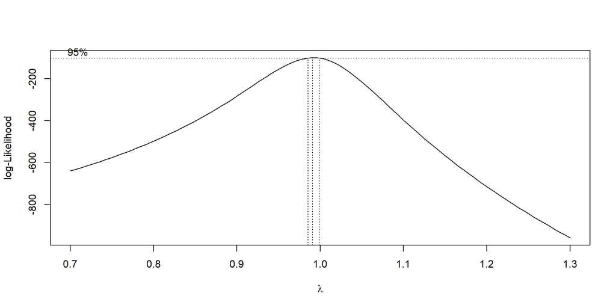

Figure 2.3 - Box-Cox Plot for rss_fwd_model

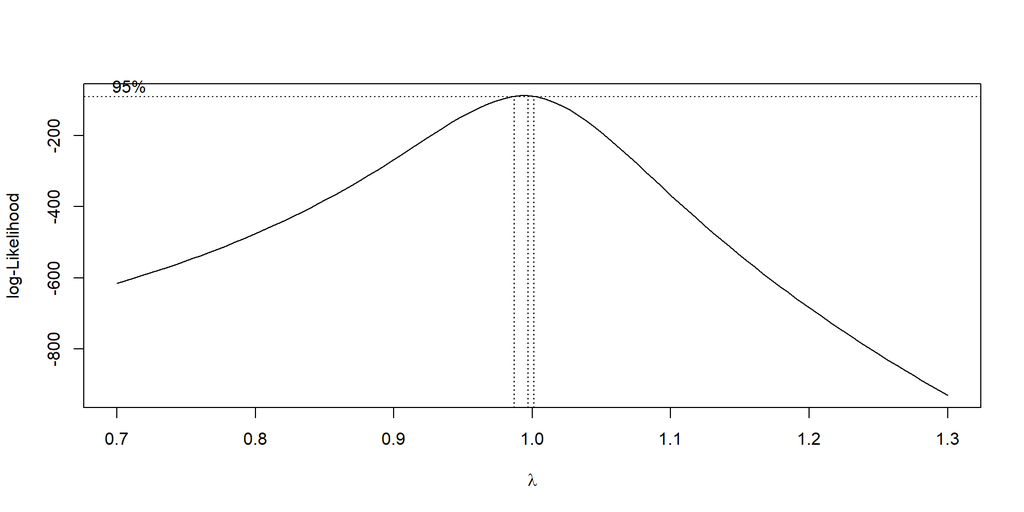

Figure 2.4 - Box-Cox Plot for aic_fwd_model

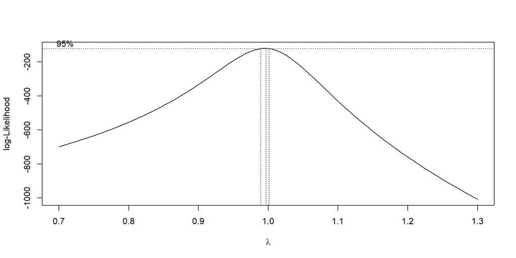

Figure 2.5 - Box-Cox Plot for bic_fwd_model

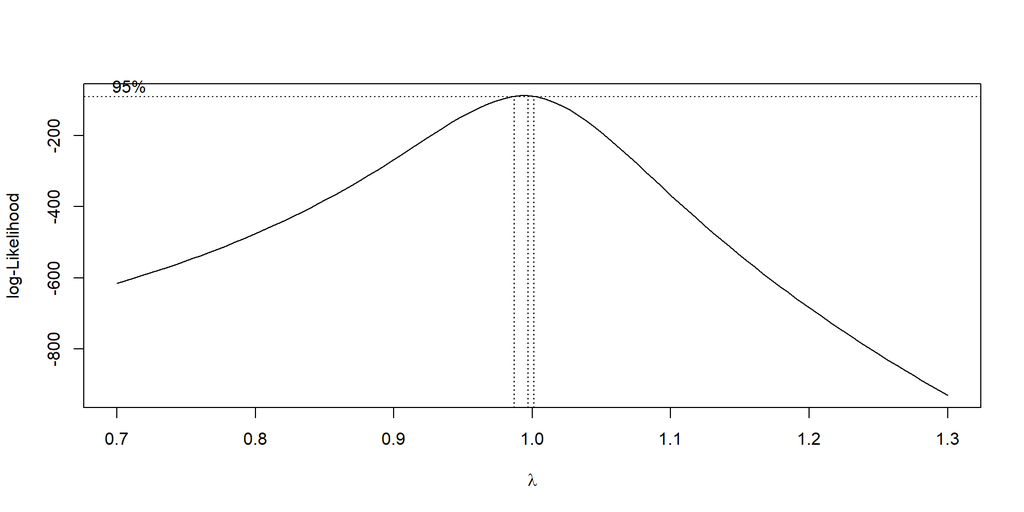

Figure 2.6 - Box-Cox Plot for aic_bwd_model

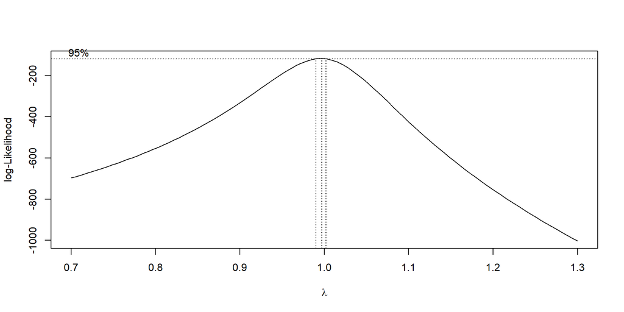

Figure 2.7 - Box-Cox Plot for bic_bwd_model

Figures 2.3 to 2.7 show the Box-Cox plots for each of the five additive models. We can see that in all plots the calculated $\lambda$ is very close to 1. This suggests that the Box-Cox method does not necessarily indicate that a transform is needed. To understand if this transformation may still be of interest, we will examine the Fitted vs Residual Plots, and the Q-Q plots for the 5 models previously selected.

```r
diagnostics = function(model, pcol= 2, lcol = 1, alpha = 0.05, plotit = TRUE, testit = TRUE){
  if (plotit == TRUE){
    par(mfrow = c(1, 2))
    plot(fitted(model), resid(model), col = pcol, pch = 20,
         xlab = "Fitted", ylab = "Residuals", main = "Fitted vs Residuals")
    abline(h = 0, col = lcol, lwd = 2)
    qqnorm(resid(model), main = "Normal Q-Q Plot", col = pcol)
    qqline(resid(model), col = lcol, lwd = 2)
  }
  if (testit == TRUE){
    shapiro_p_value = shapiro.test(resid(model))$p.value
    bp_p_value      = bptest(model)$p.value
    bp_decision      = ifelse(bp_p_value < alpha, "Reject Equal Variance - Bad", "Fail to Equal Variance-Good")
    shapiro_decision = ifelse(shapiro_p_value < alpha, "Reject Normality - Bad", "Fail to Reject Normality- Good")

    return_val = list(shapiro_p_value = shapiro_p_value, bp_p_value = bp_p_value, bp_decision = bp_decision, shapiro_decision = shapiro_decision)
    return_val
  }
}
```

In the fitted vs residuls plots shown above for the model `rss_fwd_model`, we do appear to see an increasing variance.

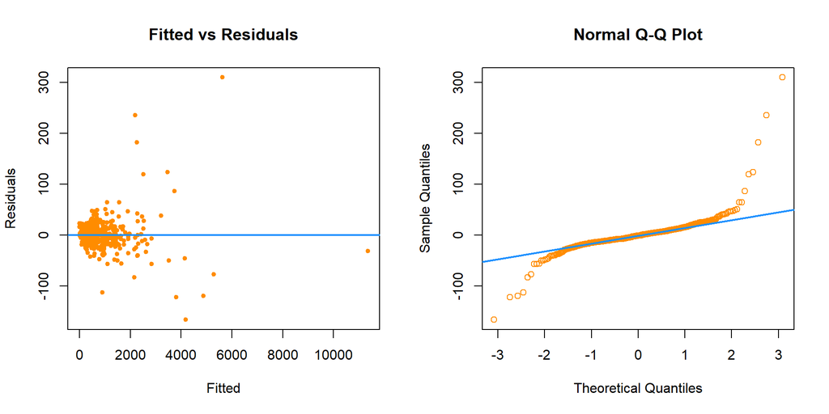

```
## $shapiro_p_value
## [1] 4.9e-29
##
## $bp_p_value
##      BP
## 9.9e-28
##
## $bp_decision
##                            BP
## "Reject Equal Variance - Bad"
##
## $shapiro_decision
## [1] "Reject Normality - Bad"
```

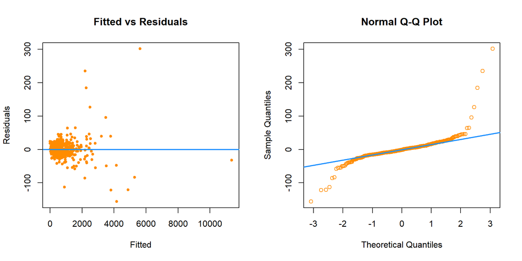

```
## $shapiro_p_value
## [1] 4.9e-29
##
## $bp_p_value
##      BP
## 7.9e-25
##
## $bp_decision
##                            BP
## "Reject Equal Variance - Bad"
##
## $shapiro_decision
## [1] "Reject Normality - Bad"
```

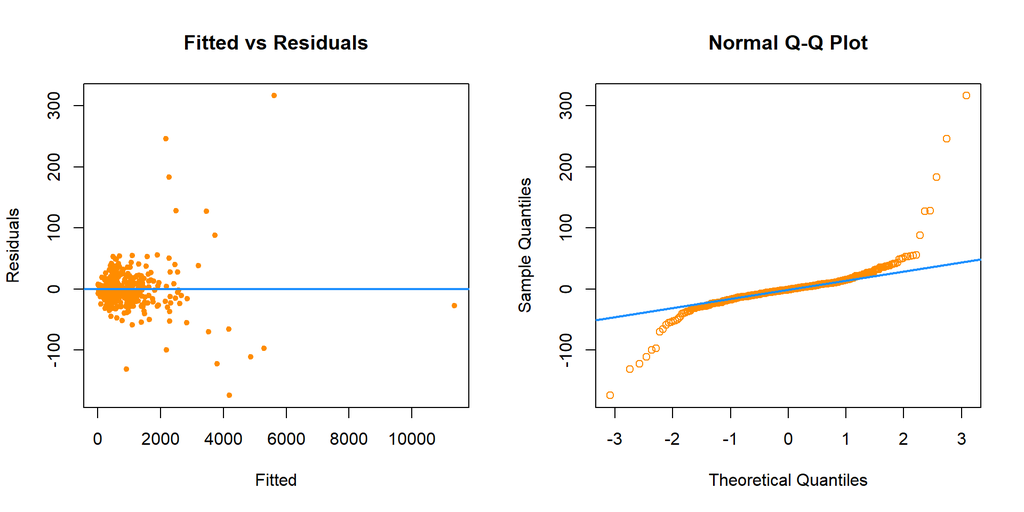

```
## $shapiro_p_value
## [1] 6e-29
##
## $bp_p_value
##      BP
## 7.3e-34
##
## $bp_decision
##                            BP
## "Reject Equal Variance - Bad"
##
## $shapiro_decision
## [1] "Reject Normality - Bad"
```

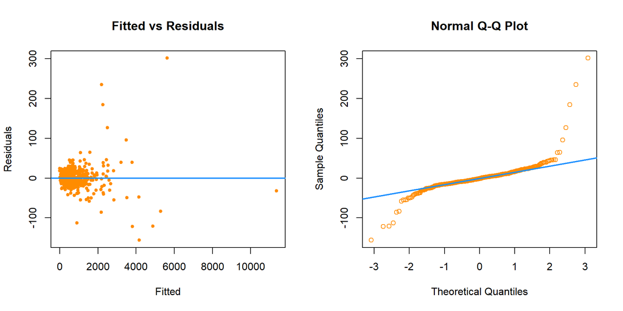

```
## $shapiro_p_value
## [1] 4.9e-29
##
## $bp_p_value
##      BP
## 7.9e-25
##
## $bp_decision
##                            BP
## "Reject Equal Variance - Bad"
##
## $shapiro_decision
## [1] "Reject Normality - Bad"
```

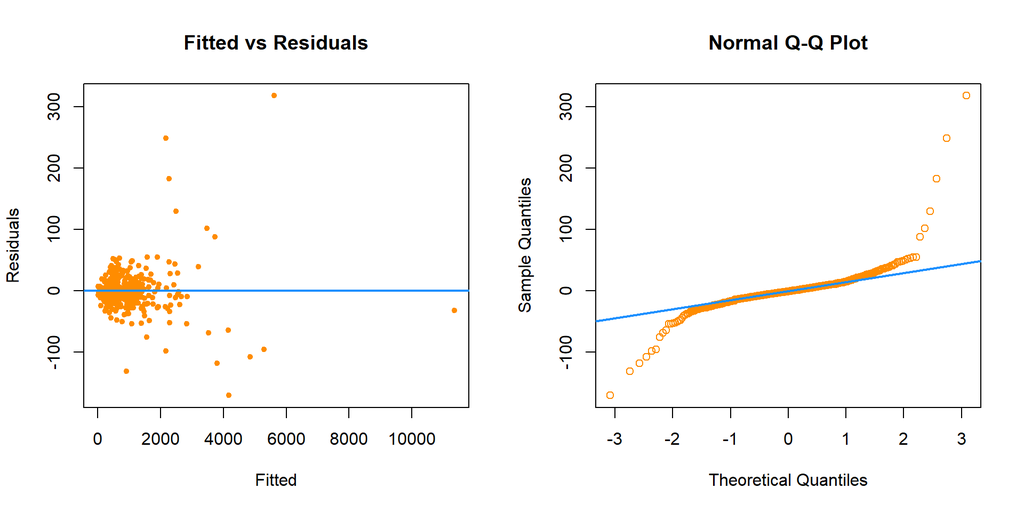

```
## $shapiro_p_value
## [1] 7e-29
##
## $bp_p_value
##      BP
## 6.8e-31
##
## $bp_decision
##                            BP
## "Reject Equal Variance - Bad"
##
## $shapiro_decision
## [1] "Reject Normality - Bad"
```

While the residuals appear in general to be centered around 0, we can see there does appear to be a pattern of increasing variance as the fitted values increase, suggesting that a log transformation of the response variable could be helpful.With this information, and given that we have variables that span multiple orders of magnitude, we are going to continue with trying different model transformations.

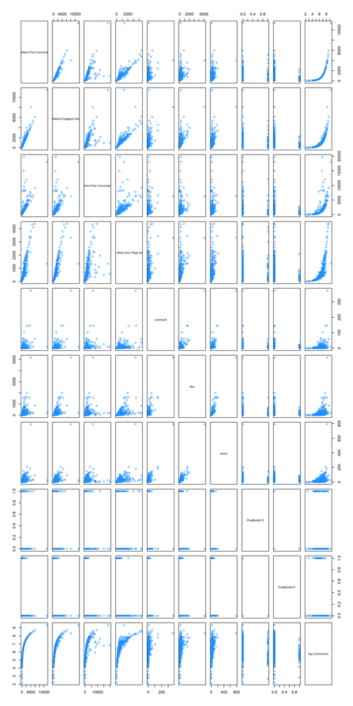

####Table 2.9

Table 2.9 - Transformation Analysis

| Model Formula | Shapiro-Wilk p-value | BP p-value | LOOCV | R^2_adj |
| --- | --- | --- | --- | --- |
| log(Lifetime.Post.Consumers) ~ Lifetime.Engaged.Users + I(Lifetime.Engaged.Users^2) | 0.00 | 0.00 | 0.60 | 0.75 |
| log(Lifetime.Post.Consumers) ~ Lifetime.Engaged.Users + I(Lifetime.Engaged.Users^2) + I(Lifetime.Engaged.Users^3) | 0.00 | 0.00 | 0.74 | 0.84 |
| log(Lifetime.Post.Consumers) ~ Lifetime.Engaged.Users + log(Lifetime.Engaged.Users) | 0.00 | 0.01 | 0.16 | 0.97 |
| log(Lifetime.Post.Consumers) ~ log(Lifetime.Engaged.Users) | 0.00 | 0.08 | 0.16 | 0.97 |
| log(Lifetime.Post.Consumers) ~ Lifetime.People.who.have.liked.your.Page.and.engaged.with.your.post + I(Lifetime.People.who.have.liked.your.Page.and.engaged.with.your.post^2) | 0.00 | 0.00 | 0.50 | 0.70 |
| log(Lifetime.Post.Consumers) ~ Lifetime.People.who.have.liked.your.Page.and.engaged.with.your.post + I(Lifetime.People.who.have.liked.your.Page.and.engaged.with.your.post^2) + I(Lifetime.People.who.ha… | 0.00 | 0.00 | 0.41 | 0.80 |
| log(Lifetime.Post.Consumers) ~ Lifetime.People.who.have.liked.your.Page.and.engaged.with.your.post + log(Lifetime.People.who.have.liked.your.Page.and.engaged.with.your.post) | 0.00 | 0.15 | 0.30 | 0.89 |
| log(Lifetime.Post.Consumers) ~ log(Lifetime.People.who.have.liked.your.Page.and.engaged.with.your.post) | 0.00 | 0.08 | 0.31 | 0.88 |
| log(Lifetime.Post.Consumers) ~ comment + I(comment^2) | 0.00 | 0.92 | 1.20 | 0.12 |
| log(Lifetime.Post.Consumers) ~ comment + I(comment^2) + I(comment^3) | 0.00 | 0.64 | 8.46 | 0.15 |
| log(Lifetime.Post.Consumers) ~ comment + log(comment) | 0.00 | 0.02 | 0.81 | 0.19 |
| log(Lifetime.Post.Consumers) ~ log(comment) | 0.00 | 0.01 | 0.81 | 0.20 |
| log(Lifetime.Post.Consumers) ~ like + I(like^2) | 0.00 | 0.44 | 1.56 | 0.17 |
| log(Lifetime.Post.Consumers) ~ like + I(like^2) + I(like^3) | 0.00 | 0.09 | 7.88 | 0.23 |
| log(Lifetime.Post.Consumers) ~ like + log(like) | 0.73 | 0.01 | 0.73 | 0.35 |
| log(Lifetime.Post.Consumers) ~ log(like) | 0.71 | 0.00 | 0.72 | 0.35 |
| log(Lifetime.Post.Consumers) ~ share + I(share^2) | 0.00 | 0.02 | 2.21 | 0.21 |
| log(Lifetime.Post.Consumers) ~ share + I(share^2) + I(share^3) | 0.00 | 0.00 | 16.94 | 0.23 |
| log(Lifetime.Post.Consumers) ~ share + log(share) | 0.02 | 0.00 | 0.76 | 0.29 |
| log(Lifetime.Post.Consumers) ~ log(share) | 0.03 | 0.00 | 0.76 | 0.29 |

[Table 2.9] shows the results of building simple models using polynomial and log transforms for the predictors of interest. We can clearly see that some perform better than others depending on which metric we are looking at.

```r
model_zach = lm(log(Lifetime.Post.Consumers) ~ like + log(like) + comment + log(comment) +
    Paid, data = adj_complete_data)

bptest(model_zach)
```

```
##
##  studentized Breusch-Pagan test
##
## data:  model_zach
## BP = 13, df = 5, p-value = 0.03
```

```r
shapiro.test(resid(model_zach))
```

```
##
##  Shapiro-Wilk normality test
##
## data:  resid(model_zach)
## W = 1, p-value = 0.9
```

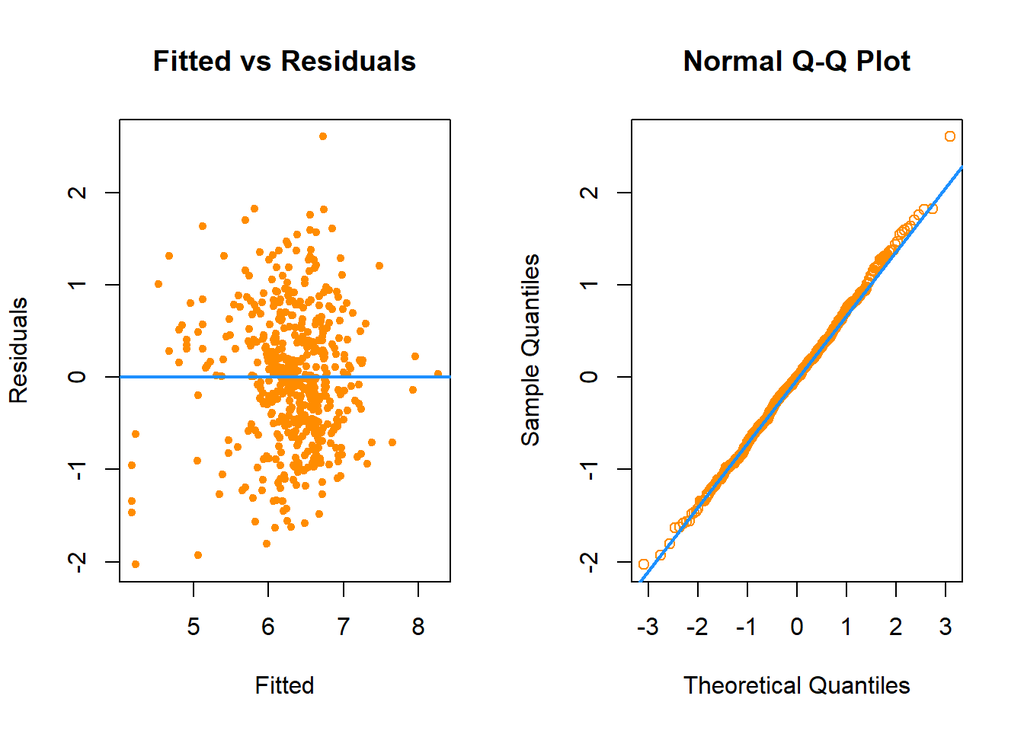

```
## $shapiro_p_value
## [1] 0.92
##
## $bp_p_value
##    BP
## 0.027
##
## $bp_decision
##                            BP
## "Reject Equal Variance - Bad"
##
## $shapiro_decision
## [1] "Fail to Reject Normality- Good"
```

```r
diagnostics(model_zach, pcol = "darkorange", lcol = "dodgerblue", plotit = TRUE)
```

```r
model_month11 = lm(log(Lifetime.Post.Consumers) ~ like + log(like) + log(share) + share
                 + PostMonth11, data = adj_complete_data)

summary(model_month11)
```

```
##
## Call:
## lm(formula = log(Lifetime.Post.Consumers) ~ like + log(like) +
##     log(share) + share + PostMonth11, data = adj_complete_data)
##
## Residuals:
##    Min     1Q Median     3Q    Max
## -2.053 -0.390 -0.023  0.410  2.632
##
## Coefficients:
##              Estimate Std. Error t value Pr(>|t|)
## (Intercept)  4.136823   0.150811   27.43  < 2e-16 ***
## like        -0.000769   0.000285   -2.70   0.0073 **
## log(like)    0.540577   0.070358    7.68  8.5e-14 ***
## log(share)  -0.084906   0.083763   -1.01   0.3113
## share        0.005564   0.002177    2.56   0.0109 *
## PostMonth11 -0.753416   0.107594   -7.00  8.4e-12 ***
## ---
## Signif. codes:  0 '***' 0.001 '**' 0.01 '*' 0.05 '.' 0.1 ' ' 1
##
## Residual standard error: 0.69 on 489 degrees of freedom
## Multiple R-squared:  0.421,  Adjusted R-squared:  0.415
## F-statistic: 71.1 on 5 and 489 DF,  p-value: <2e-16
```

```r
bptest(model_month11)
```

```
##
##  studentized Breusch-Pagan test
##
## data:  model_month11
## BP = 11, df = 5, p-value = 0.06
```

```r
shapiro.test(resid(model_month11))
```

```
##
##  Shapiro-Wilk normality test
##
## data:  resid(model_month11)
## W = 1, p-value = 0.07
```

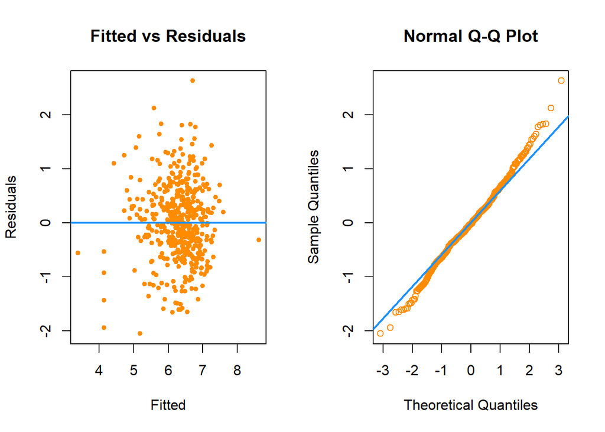

```
## $shapiro_p_value
## [1] 0.073
##
## $bp_p_value
##   BP
## 0.06
##
## $bp_decision
##                            BP
## "Fail to Equal Variance-Good"
##
## $shapiro_decision
## [1] "Fail to Reject Normality- Good"
```

```r
diagnostics(model_month11, pcol = "darkorange", lcol = "dodgerblue", plotit = TRUE)
```

```r
model_month11_b = lm(log(Lifetime.Post.Consumers) ~   log(like) +
                 + PostMonth11, data = adj_complete_data)

summary(model_month11_b)
```

```
##
## Call:
## lm(formula = log(Lifetime.Post.Consumers) ~ log(like) + +PostMonth11,
##     data = adj_complete_data)
##
## Residuals:
##     Min      1Q  Median      3Q     Max
## -2.0865 -0.4015 -0.0295  0.4163  2.6264
##
## Coefficients:
##             Estimate Std. Error t value Pr(>|t|)
## (Intercept)   4.2838     0.1242   34.49   <2e-16 ***
## log(like)     0.4585     0.0263   17.44   <2e-16 ***
## PostMonth11  -0.7408     0.1079   -6.87    2e-11 ***
## ---
## Signif. codes:  0 '***' 0.001 '**' 0.01 '*' 0.05 '.' 0.1 ' ' 1
##
## Residual standard error: 0.69 on 492 degrees of freedom
## Multiple R-squared:  0.411,  Adjusted R-squared:  0.409
## F-statistic:  172 on 2 and 492 DF,  p-value: <2e-16
```

```r
bptest(model_month11_b)
```

```
##
##  studentized Breusch-Pagan test
##
## data:  model_month11_b
## BP = 9, df = 2, p-value = 0.009
```

```r
shapiro.test(resid(model_month11_b))
```

```
##
##  Shapiro-Wilk normality test
##
## data:  resid(model_month11_b)
## W = 1, p-value = 0.08
```

```r
diagnostics(model_month11_b, pcol = "darkorange", lcol = "dodgerblue", plotit = TRUE)
```

[output not shown]

```
## $shapiro_p_value
## [1] 0.078
##
## $bp_p_value
##     BP
## 0.0091
##
## $bp_decision
##                            BP
## "Reject Equal Variance - Bad"
##
## $shapiro_decision
## [1] "Fail to Reject Normality- Good"
```

```r
##############
model_month11_b = lm(log(Lifetime.Post.Consumers) ~   log(like) +
                 + PostMonth11, data = adj_complete_data)

summary(model_month11_b)
```

```
##
## Call:
## lm(formula = log(Lifetime.Post.Consumers) ~ log(like) + +PostMonth11,
##     data = adj_complete_data)
##
## Residuals:
##     Min      1Q  Median      3Q     Max
## -2.0865 -0.4015 -0.0295  0.4163  2.6264
##
## Coefficients:
##             Estimate Std. Error t value Pr(>|t|)
## (Intercept)   4.2838     0.1242   34.49   <2e-16 ***
## log(like)     0.4585     0.0263   17.44   <2e-16 ***
## PostMonth11  -0.7408     0.1079   -6.87    2e-11 ***
## ---
## Signif. codes:  0 '***' 0.001 '**' 0.01 '*' 0.05 '.' 0.1 ' ' 1
##
## Residual standard error: 0.69 on 492 degrees of freedom
## Multiple R-squared:  0.411,  Adjusted R-squared:  0.409
## F-statistic:  172 on 2 and 492 DF,  p-value: <2e-16
```

```r
bptest(model_month11_b)
```

```
##
##  studentized Breusch-Pagan test
##
## data:  model_month11_b
## BP = 9, df = 2, p-value = 0.009
```

```r
shapiro.test(resid(model_month11_b))
```

```
##
##  Shapiro-Wilk normality test
##
## data:  resid(model_month11_b)
## W = 1, p-value = 0.08
```

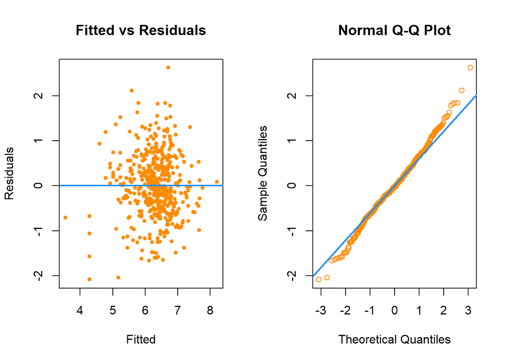

```
## $shapiro_p_value
## [1] 0.078
##
## $bp_p_value
##     BP
## 0.0091
##
## $bp_decision
##                            BP
## "Reject Equal Variance - Bad"
##
## $shapiro_decision
## [1] "Fail to Reject Normality- Good"
```

```r
diagnostics(model_month11_b, pcol = "darkorange", lcol = "dodgerblue", plotit = TRUE)
```

```r
#####
model_month11_c = lm(log(Lifetime.Post.Consumers) ~ like + log(like)  + share
                 + PostMonth11, data = adj_complete_data)

summary(model_month11_c)
```

```
##
## Call:
## lm(formula = log(Lifetime.Post.Consumers) ~ like + log(like) +
##     share + PostMonth11, data = adj_complete_data)
##
## Residuals:
##     Min      1Q  Median      3Q     Max
## -1.9954 -0.3927 -0.0194  0.4198  2.6490
##
## Coefficients:
##              Estimate Std. Error t value Pr(>|t|)
## (Intercept)  4.189024   0.141750   29.55   <2e-16 ***
## like        -0.000605   0.000235   -2.57    0.010 *
## log(like)    0.477454   0.032746   14.58   <2e-16 ***
## share        0.004180   0.001695    2.47    0.014 *
## PostMonth11 -0.750048   0.107545   -6.97    1e-11 ***
## ---
## Signif. codes:  0 '***' 0.001 '**' 0.01 '*' 0.05 '.' 0.1 ' ' 1
##
## Residual standard error: 0.69 on 490 degrees of freedom
## Multiple R-squared:  0.42,   Adjusted R-squared:  0.415
## F-statistic: 88.6 on 4 and 490 DF,  p-value: <2e-16
```

```r
bptest(model_month11_c)
```

```
##
##  studentized Breusch-Pagan test
##
## data:  model_month11_c
## BP = 11, df = 4, p-value = 0.03
```

```r
shapiro.test(resid(model_month11_c))
```

```
##
##  Shapiro-Wilk normality test
##
## data:  resid(model_month11_c)
## W = 1, p-value = 0.06
```

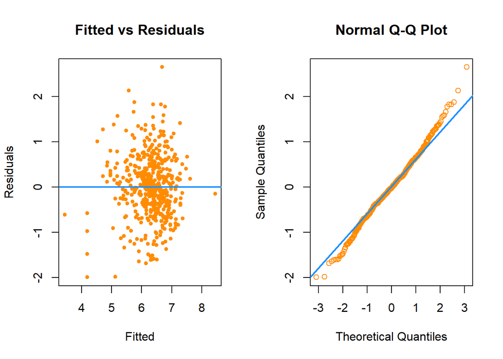

```
## $shapiro_p_value
## [1] 0.06
##
## $bp_p_value
##    BP
## 0.026
##
## $bp_decision
##                            BP
## "Reject Equal Variance - Bad"
##
## $shapiro_decision
## [1] "Fail to Reject Normality- Good"
```

```r
diagnostics(model_month11_c, pcol = "darkorange", lcol = "dodgerblue", plotit = TRUE)
```

```r
####


model_month11_d = lm(log(Lifetime.Post.Consumers) ~  + log(like)  + share  + PostMonth11, data = adj_complete_data)

summary(model_month11_d)
```

```
##
## Call:
## lm(formula = log(Lifetime.Post.Consumers) ~ +log(like) + share +
##     PostMonth11, data = adj_complete_data)
##
## Residuals:
##     Min      1Q  Median      3Q     Max
## -2.1121 -0.3946 -0.0252  0.4222  2.6351
##
## Coefficients:
##              Estimate Std. Error t value Pr(>|t|)
## (Intercept)  4.308935   0.134631   32.01  < 2e-16 ***
## log(like)    0.450386   0.031186   14.44  < 2e-16 ***
## share        0.000420   0.000863    0.49     0.63
## PostMonth11 -0.738772   0.108069   -6.84  2.4e-11 ***
## ---
## Signif. codes:  0 '***' 0.001 '**' 0.01 '*' 0.05 '.' 0.1 ' ' 1
##
## Residual standard error: 0.69 on 491 degrees of freedom
## Multiple R-squared:  0.412,  Adjusted R-squared:  0.408
## F-statistic:  115 on 3 and 491 DF,  p-value: <2e-16
```

```r
bptest(model_month11_d)
```

```
##
##  studentized Breusch-Pagan test
##
## data:  model_month11_d
## BP = 10, df = 3, p-value = 0.02
```

```r
shapiro.test(resid(model_month11_d))
```

```
##
##  Shapiro-Wilk normality test
##
## data:  resid(model_month11_d)
## W = 1, p-value = 0.07
```

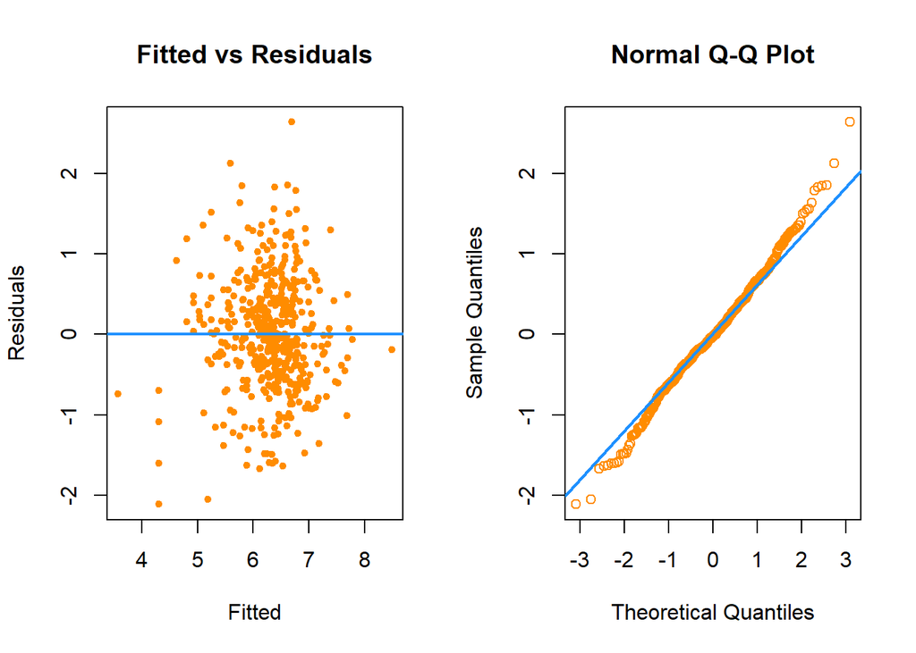

```
## $shapiro_p_value
## [1] 0.067
##
## $bp_p_value
##    BP
## 0.021
##
## $bp_decision
##                            BP
## "Reject Equal Variance - Bad"
##
## $shapiro_decision
## [1] "Fail to Reject Normality- Good"
```

```r
diagnostics(model_month11_d, pcol = "darkorange", lcol = "dodgerblue", plotit = TRUE)
```

```r
# Split data into testing and training tests
set.seed(0)
test_indicies <- sample(1:nrow(adj_complete_data), nrow(adj_complete_data)/2)
train_data    <- adj_complete_data[-test_indicies,]
test_data     <- adj_complete_data[test_indicies,]

model_month11 = lm(log(Lifetime.Post.Consumers) ~ like + log(like) + log(share) + share
                 + PostMonth11, data = train_data)

range(adj_complete_data$like)
```

```
## [1]    1 5173
```

```r
range(adj_complete_data$share)
```

```
## [1]   1 791
```

```r
range(adj_complete_data$Lifetime.Post.Consumers)
```

```
## [1]     9 11328
```

```r
diagnostics2 = function(strmodel, test, train){
  model = lm(strmodel, data = train)
  RMSE_Train = sqrt(mean((  (train$Lifetime.Post.Consumers - exp(fitted(model))) ^ 2)))
  RMSE_Test  =  sqrt(mean((test$Lifetime.Post.Consumers - exp(predict(model, newdata = test))) ^ 2))


  data.frame(strmodel, RMSE_Train, RMSE_Test)
}

(diagnostics2("log(Lifetime.Post.Consumers) ~ like + log(like) + log(share) + share
                 + PostMonth11", test = test_data, train = train_data))
```

```
##                                                                                                strmodel
## 1 log(Lifetime.Post.Consumers) ~ like + log(like) + log(share) + share \n                 + PostMonth11
##   RMSE_Train RMSE_Test
## 1        966       655
```

```r
(diagnostics2("log(Lifetime.Post.Consumers) ~  + log(like)  + share
                 + PostMonth11", test = test_data, train = train_data))
```

```
##                                                                                strmodel
## 1 log(Lifetime.Post.Consumers) ~  + log(like)  + share \n                 + PostMonth11
##   RMSE_Train RMSE_Test
## 1        974       641
```

```r
(diagnostics2("log(Lifetime.Post.Consumers) ~ like", test = test_data, train = train_data))
```

```
##                              strmodel RMSE_Train RMSE_Test
## 1 log(Lifetime.Post.Consumers) ~ like       1042     18230
```

```r
(diagnostics2("log(Lifetime.Post.Consumers) ~ Lifetime.Engaged.Users + log(Lifetime.Engaged.Users)", test = test_data, train = train_data))
```

```
##                                                                              strmodel
## 1 log(Lifetime.Post.Consumers) ~ Lifetime.Engaged.Users + log(Lifetime.Engaged.Users)
##   RMSE_Train RMSE_Test
## 1        186       269
```

```r
(diagnostics2("log(Lifetime.Post.Consumers) ~   log(like) +
                 + PostMonth11", test = test_data, train = train_data))
```

```
##                                                                         strmodel
## 1 log(Lifetime.Post.Consumers) ~   log(like) +  \n                 + PostMonth11
##   RMSE_Train RMSE_Test
## 1        962       622
```

```r
(diagnostics2("log(Lifetime.Post.Consumers) ~  + log(like)  + share  + PostMonth11", test = test_data, train = train_data))
```

```
##                                                              strmodel
## 1 log(Lifetime.Post.Consumers) ~  + log(like)  + share  + PostMonth11
##   RMSE_Train RMSE_Test
## 1        962       627
```

```r
diagnostics2("log(Lifetime.Post.Consumers) ~ like + log(like) + comment + log(comment) +
    Paid", test = test_data, train = train_data)
```

```
##                                                                                strmodel
## 1 log(Lifetime.Post.Consumers) ~ like + log(like) + comment + log(comment) + \n    Paid
##   RMSE_Train RMSE_Test
## 1        951       639
```

# **III**. Results

The confidence interval confirms what we were seeing. While we would like to reject like and log(share) and share, removing them from the model then makes the model violate the normality and equal variance assumptions.

```r
confint(model_month11, level = 0.99)
```

```
##               0.5 %   99.5 %
## (Intercept)  3.4737  4.70580
## like        -0.0018  0.00023
## log(like)    0.1908  0.78460
## log(share)  -0.3781  0.44557
## share       -0.0081  0.01597
## PostMonth11 -1.1458 -0.36567
```

```r
summary(model_month11)
```

```
##
## Call:
## lm(formula = log(Lifetime.Post.Consumers) ~ like + log(like) +
##     log(share) + share + PostMonth11, data = train_data)
##
## Residuals:
##     Min      1Q  Median      3Q     Max
## -1.9018 -0.4130 -0.0359  0.3870  2.6297
##
## Coefficients:
##              Estimate Std. Error t value Pr(>|t|)
## (Intercept)  4.089737   0.237284   17.24  < 2e-16 ***
## like        -0.000783   0.000389   -2.01    0.046 *
## log(like)    0.487705   0.114352    4.26  2.9e-05 ***
## log(share)   0.033755   0.158616    0.21    0.832
## share        0.003960   0.004627    0.86    0.393
## PostMonth11 -0.755717   0.150231   -5.03  9.5e-07 ***
## ---
## Signif. codes:  0 '***' 0.001 '**' 0.01 '*' 0.05 '.' 0.1 ' ' 1
##
## Residual standard error: 0.68 on 242 degrees of freedom
## Multiple R-squared:  0.404,  Adjusted R-squared:  0.392
## F-statistic: 32.8 on 5 and 242 DF,  p-value: <2e-16
```

```r
confint(model_month11, level = 0.73)
```

```
##              13.5 %   86.5 %
## (Intercept)  3.8274  4.35208
## like        -0.0012 -0.00035
## log(like)    0.3613  0.61413
## log(share)  -0.1416  0.20912
## share       -0.0012  0.00908
## PostMonth11 -0.9218 -0.58962
```

```r
summary(model_month11)
```

```
##
## Call:
## lm(formula = log(Lifetime.Post.Consumers) ~ like + log(like) +
##     log(share) + share + PostMonth11, data = train_data)
##
## Residuals:
##     Min      1Q  Median      3Q     Max
## -1.9018 -0.4130 -0.0359  0.3870  2.6297
##
## Coefficients:
##              Estimate Std. Error t value Pr(>|t|)
## (Intercept)  4.089737   0.237284   17.24  < 2e-16 ***
## like        -0.000783   0.000389   -2.01    0.046 *
## log(like)    0.487705   0.114352    4.26  2.9e-05 ***
## log(share)   0.033755   0.158616    0.21    0.832
## share        0.003960   0.004627    0.86    0.393
## PostMonth11 -0.755717   0.150231   -5.03  9.5e-07 ***
## ---
## Signif. codes:  0 '***' 0.001 '**' 0.01 '*' 0.05 '.' 0.1 ' ' 1
##
## Residual standard error: 0.68 on 242 degrees of freedom
## Multiple R-squared:  0.404,  Adjusted R-squared:  0.392
## F-statistic: 32.8 on 5 and 242 DF,  p-value: <2e-16
```

```r
confint(model_month11_d, level = 0.99)
```

```
##               0.5 %  99.5 %
## (Intercept)  3.9608  4.6571
## log(like)    0.3697  0.5310
## share       -0.0018  0.0027
## PostMonth11 -1.0182 -0.4593
```

```r
confint(model_zach, level = 0.52)
```

```
##                  24 %     76 %
## (Intercept)   4.05327  4.28232
## like         -0.00066 -0.00034
## log(like)     0.42763  0.49028
## comment       0.00419  0.00895
## log(comment)  0.01314  0.08055
## Paid1         0.00056  0.10309
```

```r
#qqnorm(resid(selected_model), main = "Normal Q-Q Plot (paid_model)", col = "dodgerblue")
#qqline(resid(selected_model), col = "orange", lwd = 2)
```

```r
#plot(fitted(selected_model), resid(selected_model), col = "dodgerblue", pch = 20,
#            xlab = "Fitted", ylab = "Residuals", main = "Fitted vs. Residual Values (selected_model)")
#abline(h = 0, col = "orange", lwd = 2)
```

# **IV**. Discussion

# References

[1] Moro et al., 2016) Moro, S., Rita, P., & Vala, B. (2016). Predicting social media performance metrics and evaluation of the impact on brand building: A data mining approach. Journal of Business Research, 69(9), 3341-3351.

[2] D. Dalpiaz, Applied Statistics with R, 2017-06-28. [Online] Available: http://daviddalpiaz.github.io/appliedstats/

# Appendix A - Variable Descriptions and Mappings

Table `A.1` shows the original variable names (as found in the dataset), the variable data type, and the original description of the variable. The descriptions for the variable names come from [1].

####Table A.1

Table A.1 - Dataset Description

| Variable | Type | Description |
| --- | --- | --- |
| Lifetime Post Consumers | number | The number of people who clicked anywhere in a post |
| Page total likes | numeric | Number of people who have liked the company’s page |
| Type | [Link, Photo, Status, Video] | Type of content (Link, Photo, Status, Video) |
| Category | [action, product, inspiration] | Manual content characterization |
| Post Month | numeric | Month the post was published |
| Post Weekday | numeric | Weekday the post was published |
| Post Hour | numeric | Hour the post was published |
| Paid | [yes, no] | If the company paid to Facebook for advertising |
| Lifetime Post Total Reach | number | The number of people who saw a page post (unique users) |
| Lifetime Post Total Impressions | number | Impressions are the number of times a post from a page is displayed, whether the post is clicked or not |
| Lifetime Engaged Users | number | The number of people who clicked anywhere in a post (unique users) |
| Lifetime Post Consumptions | number | The number of clicks anywhere in a post |
| Lifetime Post Impressions by people who have liked your Page | number | Total number of impressions just from people who have liked a page |
| Lifetime Post reach by people who like your Page | number | Total number of impressions just from people who have liked a page |
| Lifetime People who have liked your Page and engaged with your post | number | The number of people who have liked a Page and clicked anywhere in a post (Unique users) |
| comment | number | Number of comments on the publication |
| like | number | Number of “Likes” on the publication |
| share | number | Number of times the publication was shared. |
| Total Interactions | number | The sum of “likes,”comments," and “shares” of the post |